# Shiny Kickstarter Project

Susmitha Saripalli

2/5/2019

## Kickstarter Projects

This is a look at Kickstarter projects and trying to find a pattern behind the successes.

My main goal for this project was to look for a category-independent trend of raised money for Kickstarter projects. Unfortunately, the only category-independent data I had to look at was time dependent. In analyzing just time dependent data, there is no correlation between length of open projects and percentage of money raised.

## Category Success

My dataset described almost 375,000 kickstarter projects from 2008 to 2018. Some categories definitely are more popular and more successful than others, as you can see here:

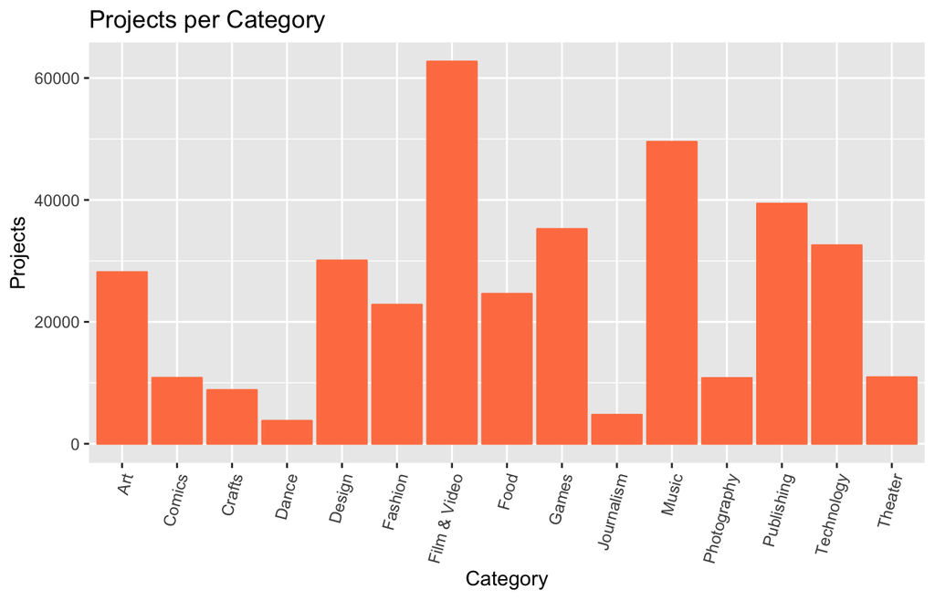

## Most Popular Categories

You can see in the app that the most popular categories are Film & Video and Music. You can also see that while Film & Video and Music have the most number of projects, Games has the highest number of backers. This incongruence would mean that Games have a much larger number of backers, making it one of the most popular Kickstarter categories on the site.

Very few categories have more successful projects than failed, like Music, Comics, and Theater. Technology has the lowest project success to project failure ratio.

## Conclusion

In conclusion, more than anything about the trends of kickstarter projects, I think this project shows how important it is to analyze your data to make sure they are accurately represented in the graphs. Looking at different graphs and looking at the same graphs with different scales result in different conclusions to be made. But as far as kickstarter goes, it seems Games have the widest and most enthusiastic audience, as Games also has the highest percentage of the goal reached at 40,000% of the goal raised for Energy Hook. Although this too is not honest representation as the goal requested was $1. The actual most money gained for a project was a smartwatch in the Design category at $20,338,986 in 2015.